# 3-polish

Huize Zhang

25/02/2020

## Preliminary

- I write a `search_polish()` function aiming to fining the global maximum after using `search_geodesic()`. This is implemented inside the `animate()` function.

However, using it on the simulated data `geodesic_alpha` from `2-alpha_analysis` shows that the algorithm is not effective on picking the global maximum, see below:

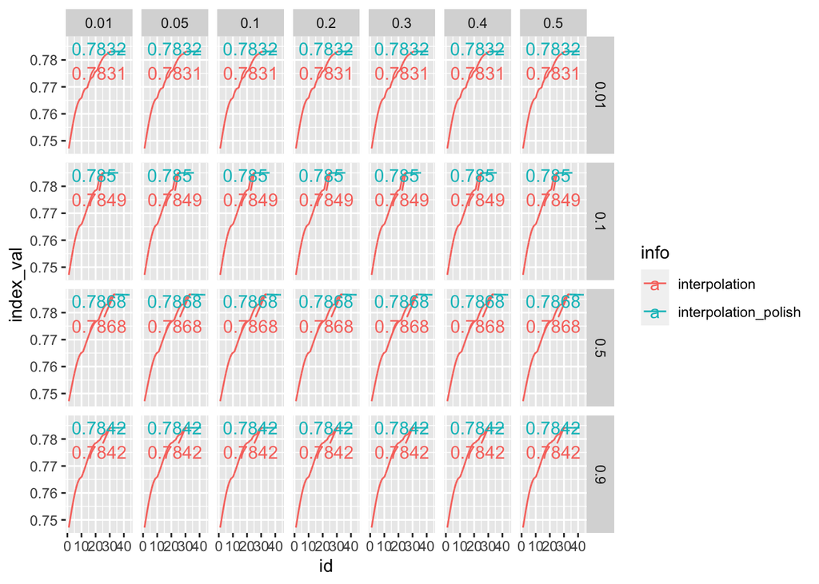

```r
geodesic_clean <- geodesic_polished %>%
  filter(info %in% c("interpolation", "interpolation_polish")) %>%
  mutate(stepS = as.factor(stepS))

geodesic_interp <- geodesic_clean %>%
  group_by(stepS, polish_alpha) %>%
  mutate(id = row_number())

best <- geodesic_clean %>%
  group_by(stepS, polish_alpha, info) %>%
  mutate(id = row_number()) %>%
  filter(index_val == max(index_val))

geodesic_interp %>%
  ggplot(aes(x = id, y = index_val, col = info, group = stepS)) +
  geom_path() +
  ggrepel::geom_text_repel(data = best, aes(label = round(index_val, 4))) +
  facet_grid(stepS ~ polish_alpha)
```

Adding the polish step doesn’t find a better basis for all the step_polish value and all the alpha value. This makes me want to understand more on how the ending interpolation bases locate for different alpha value.

## Version 2

A polishing procedure is implemented for the final projection in 1D projection. The polishing step is described as follows:

1. Set `grid_gap = 0.002` and `grid_vec <- c(-2, -1, 0, 1, 2) * grid_gap`
2. Apply this to all the element of the basis to form a grid.
3. Calculate the index value for each combination and output the basis with the largest index_val
4. repeat 1-3 for 10 times

This grid-based searching approach is not suitable for high dimensional data because grid searching sets the grid in a cubic while the sampling space in our case is a sphere.

A better approach is to prescribe an angle that determines a radius of the searching sphere. This angle-based polishing is implemented in version 3

## Version 3

### Procedure

Given the last basis (current) from tour and interpolation, `search_polish()` looks for bases nearby with higher index value.

1. `polish_alpha` defines the angle to move from the current basis to a randomly generated basis in percentage. `iter` defines the number of randomly generated sample to take.
2. Form a grid value of `alpha_seq <- seq(0, polish_alpha, by = polish_alpha/10)` and generate `iter` number of bases for each `alpha` in `alpha_seq` (thus both inside and on the boundary)
3. Once the nearby bases are generated, compute the corresponding `index_val` and compare with `cur_index`.
4. The basis with the largest `index_val` become the “current” basis in the next round.
5. Repeat 2-4 for `nloop` number of times.

### Examples

#### 1D projection with `x1, x2, x8: x10` using `holes()` index

```r
set.seed(123456)
polish_holes <- animate_dist(data, tour_path = guided_tour(holes(), d = 1,
                                                search_f = search_geodesic_latest),
                  rescale = FALSE, polish = TRUE, nloop = 20, polish_alpha = 0.005)
```

```r
options(pillar.sigfig = 7)
polish_holes %>% filter(info == "polish")
```

```
## # A tibble: 14 x 6
##    basis             index_val tries info    loop    id
##    <list>                <dbl> <dbl> <chr>  <dbl> <int>
##  1 <dbl[,1] [5 × 1]> 0.9370249    NA polish     0   653
##  2 <dbl[,1] [5 × 1]> 0.9372219    NA polish     1   654
##  3 <dbl[,1] [5 × 1]> 0.9374110    NA polish     2   655
##  4 <dbl[,1] [5 × 1]> 0.9375623    NA polish     3   656
##  5 <dbl[,1] [5 × 1]> 0.9377160    NA polish     4   657
##  6 <dbl[,1] [5 × 1]> 0.9378502    NA polish     5   658
##  7 <dbl[,1] [5 × 1]> 0.9379605    NA polish     6   659
##  8 <dbl[,1] [5 × 1]> 0.9380520    NA polish     7   660
##  9 <dbl[,1] [5 × 1]> 0.9381198    NA polish     8   661
## 10 <dbl[,1] [5 × 1]> 0.9381668    NA polish     9   662
## 11 <dbl[,1] [5 × 1]> 0.9381952    NA polish    10   663
## 12 <dbl[,1] [5 × 1]> 0.9382039    NA polish    11   664
## 13 <dbl[,1] [5 × 1]> 0.9382047    NA polish    12   665
## 14 <dbl[,1] [5 × 1]> 0.9382048    NA polish    13   666
```

```r
basis <- polish_holes %>% filter(info == "polish") %>% pull(basis)
basis_0 <- matrix(c(0, 1, 0, 0, 0))
basis_1 <- basis %>% first()
basis_2 <- basis %>% last()
basis_1
```

```
##             [,1]
## [1,]  0.04886521
## [2,] -0.99248463
## [3,]  0.03863394
## [4,]  0.09575034
## [5,]  0.04388333
```

```r
basis_2
```

```
##             [,1]
## [1,]  0.03790878
## [2,] -0.99375409
## [3,]  0.03569638
## [4,]  0.06214616
## [5,]  0.07667699
```

```r
tourr:::proj_dist(basis_1, basis_2)
```

```
## [1] 0.0683167
```

```r
tourr:::proj_dist(basis_0, basis_1)
```

```
## [1] 0.1730564
```

```r
tourr:::proj_dist(basis_0, basis_2)
```

```
## [1] 0.1578152
```

#### 2D projection with `x1, x2, x7: x10` using `holes()` index

```r
set.seed(123456)
polish_holes_mult <- animate_dist(data_mult[,c(1,2,7:10)], tour_path = guided_tour(holes(), d = 2,
                                                search_f = search_geodesic_latest),
                  rescale = FALSE, polish = TRUE, nloop = 30, polish_alpha = 0.05)
```

```r
polish_holes_mult %>% filter(info == "polish")
```

```
## # A tibble: 17 x 6
##    basis             index_val tries info    loop    id
##    <list>                <dbl> <dbl> <chr>  <dbl> <int>
##  1 <dbl[,2] [6 × 2]> 0.9155285    NA polish     0   860
##  2 <dbl[,2] [6 × 2]> 0.9217620    NA polish     1   861
##  3 <dbl[,2] [6 × 2]> 0.9279487    NA polish     2   862
##  4 <dbl[,2] [6 × 2]> 0.9335799    NA polish     3   863
##  5 <dbl[,2] [6 × 2]> 0.9384028    NA polish     4   864
##  6 <dbl[,2] [6 × 2]> 0.9435326    NA polish     5   865
##  7 <dbl[,2] [6 × 2]> 0.9484385    NA polish     6   866
##  8 <dbl[,2] [6 × 2]> 0.9519519    NA polish     7   867
##  9 <dbl[,2] [6 × 2]> 0.9550186    NA polish     8   868
## 10 <dbl[,2] [6 × 2]> 0.9583593    NA polish     9   869
## 11 <dbl[,2] [6 × 2]> 0.9603586    NA polish    10   870
## 12 <dbl[,2] [6 × 2]> 0.9620815    NA polish    11   871
## 13 <dbl[,2] [6 × 2]> 0.9629179    NA polish    12   872
## 14 <dbl[,2] [6 × 2]> 0.9630870    NA polish    13   873
## 15 <dbl[,2] [6 × 2]> 0.9631485    NA polish    14   874
## 16 <dbl[,2] [6 × 2]> 0.9631863    NA polish    15   875
## 17 <dbl[,2] [6 × 2]> 0.9631890    NA polish    16   876
```

```r
basis <- polish_holes_mult %>% filter(info == "polish") %>% pull(basis)

basis_0 <- matrix(c(0, 1, 0, 0, 0, 0,
                    0, 0, 1, 0, 0, 0), nrow = 6, ncol = 2) # theoretical optimal
basis_1 <- basis %>% first() # last basis from interpolation
basis_2 <- basis %>% last() # last basis after polishing

basis_1
```

```
##             [,1]        [,2]
## [1,]  0.18868153 -0.03837976
## [2,] -0.37599513  0.91265502
## [3,]  0.78543099  0.36422425
## [4,]  0.44991593  0.15399390
## [5,]  0.04824602 -0.03385940
## [6,]  0.03705508 -0.08982159
```

```r
basis_2
```

```
##             [,1]        [,2]
## [1,] -0.01472936 -0.01336101
## [2,] -0.40766032  0.91150426
## [3,]  0.91048130  0.40692283
## [4,]  0.02266436  0.03689678
## [5,]  0.04883816 -0.02853246
## [6,] -0.04148581 -0.03492574
```

```r
tourr:::proj_dist(basis_1, basis_2)
```

```
## [1] 0.7061281
```

```r
tourr:::proj_dist(basis_0, basis_1)
```

```
## [1] 0.7431384
```

```r
tourr:::proj_dist(basis_0, basis_2)
```

```
## [1] 0.1296971
```

ToDo:

1. Programming issue with accessing `index()`

Currently, the `index()` function is declared inside the `generator()` and I don’t know how to programmatically make it available in `search_polish()` - which is a function NOT part of the `guided_tour()` process. Also, we probably don’t want to specify `holes()` twice inside the `animate_dist()`.

2. searching scheme

We could think about adding a more structured searching scheme with cooling rate or more use more advanced algorithm but playing around with parameters: `polish_alpha` and `nloop` would give a pretty good result. Thus don’t think it is necessary.

## Version 3 with all the nearby bases outputted

I allow version 3 to output all the nearby bases to assess the efficiency of the sampling. The following plot shows the sampling of each loop in a panel and x-axis represents the distance between the current basis and the sampled basis. y-axis represents the index_val and the scale is different for each panel. Start from panel 1, the dot with proj_dist = 0 is the last basis from search_geodesic_latest & interpolation and 100 samples are taken at each alpha level. The point with the largest index value becomes the current point in panel 2 and this process keeps going for `nloop = 30` times.

The shape of all the points in one panel is either a cone-like or meteor-like shape and this is explanable. In the initial stage of polishing, the basis is far from the one with the highest index_val, taking random samples around it will gives some points with higher index_val and some with lower. This creates the cone-like shape in the first few panels. In the end of polishing, the current basis is almost at the peak of the mountain. Going in any direction is likely to cause a decline in the index_val and the further one goes, the lower the index_val would be.

The messages from this plot are two-fold:

1. At the initial stage of polishing, a larger alpha value is more efficient
2. When it coems to the end, a smaller alpha value is more likely to find a higher index_val

Based on these two messages, I no longer use a vector of alpha value in the sampling of nearby basis. Rather a relatively large alpha value is used to initialise the polishing procedure and a cooling parameter to adjust.

The current `search_polish()` also implement the percentage change improvement. If the percentage change is less than 0.001, the cooling parameter will work to reduce the alpha value and continue the searching. It will end if the number of iteration > `nloop` or `polish_alpha < 0.001`.

```r
set.seed(123456)
polish_holes_old_mult <- tourr::animate_dist(data_mult[,c(1,2,7:10)], tour_path = guided_tour(holes(), d = 2,
                                                                                              search_f = search_geodesic_latest),
                                             rescale = FALSE, polish = TRUE,
                                             nloop = 30, polish_alpha = 0.05)

polish_holes_old_mult_record <- polish_holes_old_mult$record
polish_holes_old_mult_sim <- polish_holes_old_mult$sim
```

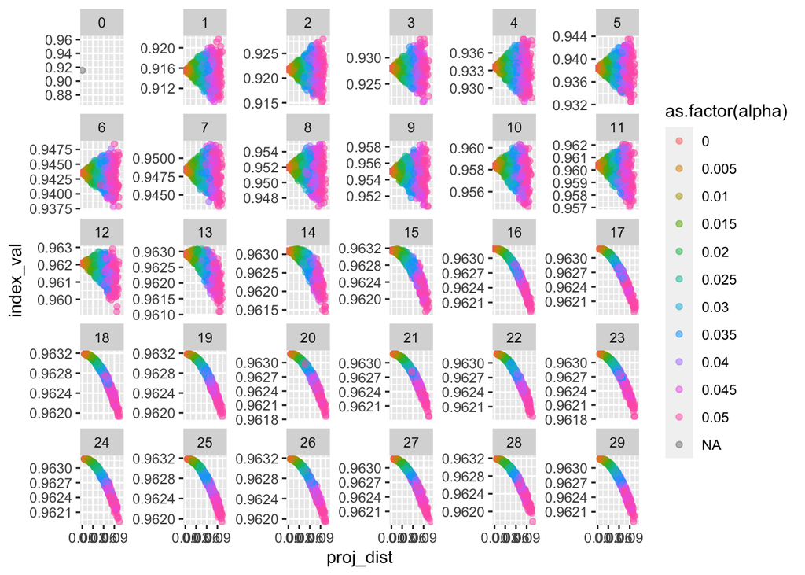

```r
polish <- polish_holes_old_mult_record %>% filter(info == "polish")

sim <- polish_holes_old_mult_sim %>%
  mutate(basis_id = case_when(loop == 0 ~ 1,
                              between(loop, 1, 16) ~ loop,
                              loop > 16 ~ 16),
         proj_dist = map2_dbl(basis, basis_id, ~tourr::proj_dist(polish$basis[[.y]], .x)))

sim %>%
  ggplot(aes(x = proj_dist, y = index_val, col = as.factor(alpha))) +
  geom_point(alpha = 0.5) +
  facet_wrap(vars(loop), scales = "free_y")
```

After these modification, search_polish is working well.

```r
# search_polish modified
set.seed(123456)
polish_modified_mult <- tourr::animate_dist(data_mult[,c(1,2,7:10)],
                                            tour_path = guided_tour(holes(), d = 2,
                                                                    search_f = search_geodesic_latest),
                                            rescale = FALSE, polish = TRUE,
                                            nloop = 30, polish_alpha = 0.05)

polish_mult_modified_record <- polish_modified_mult$record
polish_mult_modified_sim <- polish_modified_mult$sim
```

```r
polish_mult_modified_record %>% filter(info == "polish")
```

```
## # A tibble: 17 x 7
##    basis             index_val tries info    loop    id       alpha
##    <list>                <dbl> <dbl> <chr>  <dbl> <int>       <dbl>
##  1 <dbl[,2] [6 × 2]> 0.9155285    NA polish     0   860 NA
##  2 <dbl[,2] [6 × 2]> 0.9222563    NA polish     1   861  0.05
##  3 <dbl[,2] [6 × 2]> 0.9288057    NA polish     2   862  0.05
##  4 <dbl[,2] [6 × 2]> 0.9349320    NA polish     3   863  0.05
##  5 <dbl[,2] [6 × 2]> 0.9409835    NA polish     4   864  0.05
##  6 <dbl[,2] [6 × 2]> 0.9462558    NA polish     5   865  0.05
##  7 <dbl[,2] [6 × 2]> 0.9508007    NA polish     6   866  0.05
##  8 <dbl[,2] [6 × 2]> 0.9547636    NA polish     7   867  0.05
##  9 <dbl[,2] [6 × 2]> 0.9586229    NA polish     8   868  0.05
## 10 <dbl[,2] [6 × 2]> 0.9612287    NA polish     9   869  0.05
## 11 <dbl[,2] [6 × 2]> 0.9625856    NA polish    10   870  0.05
## 12 <dbl[,2] [6 × 2]> 0.9629105    NA polish    11   871  0.05
## 13 <dbl[,2] [6 × 2]> 0.9630264    NA polish    12   872  0.045
## 14 <dbl[,2] [6 × 2]> 0.9631358    NA polish    13   873  0.03645
## 15 <dbl[,2] [6 × 2]> 0.9631389    NA polish    14   874  0.02657205
## 16 <dbl[,2] [6 × 2]> 0.9631771    NA polish    15   875  0.01743392
## 17 <dbl[,2] [6 × 2]> 0.9631858    NA polish    16   876  0.01029456
```

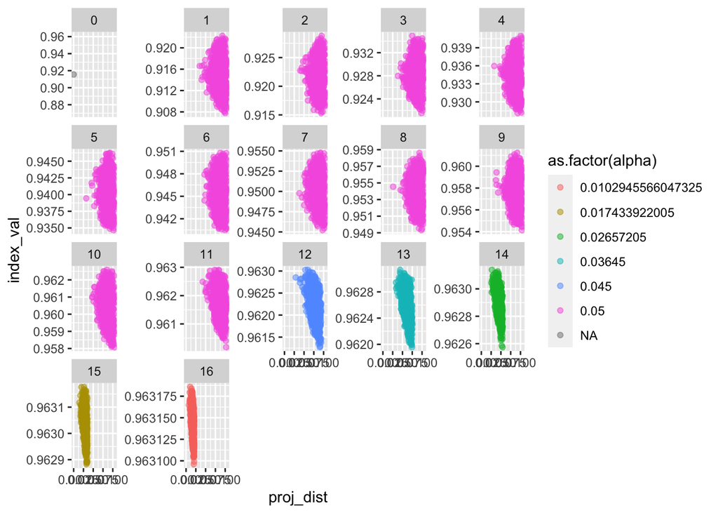

```r
polish <- polish_mult_modified_record %>% filter(info == "polish")

sim <- polish_mult_modified_sim %>%
  mutate(basis_id = case_when(loop == 0 ~ 1,
                              between(loop, 1, 16) ~ loop,
                              loop > 16 ~ 16),
         proj_dist = map2_dbl(basis, basis_id, ~tourr::proj_dist(polish$basis[[.y]], .x)))

sim %>%
  ggplot(aes(x = proj_dist, y = index_val, col = as.factor(alpha))) +
  geom_point(alpha = 0.5) +
  facet_wrap(vars(loop), scales = "free_y")
```